# Judicial Review and Democracy

Do Courts Care About the Policy Process?

Devin Judge-Lord

### 1. The role of public participation in democracy and its effects on policy

### 2. The role of courts in a democracy and how they judge policy & policymaking

### 3. Jurisprudential regimes

> “deference should be accorded to the agency’s interpretation … the regulatory scheme is technical and complex, the agency considered the matter in a detailed and reasoned fashion, and the decision involves reconciling conflicting policies” - *Chevron v. NRDC*

> “the degree of the agency’s care, its consistency, formality, and relative expertness…the fairness and deliberation that should underlie a pronouncement of such force (APA notice and comment is ‘designed to assure due deliberation’).” *US v. Mead Corp.*

## Data (so far)

All 517 Administrative Law<sup>1</sup> SCOTUS cases + a random sample of 175 federal circuit court cases 1969-2025.

- 100+ *case factors*
  - Parties, briefs, citations, opinions, outcomes
  - Nature of the agency action at issue (Rulemaking, Ratemaking, Licensing, Adjudication, etc.)
  - Discussion of legislative process, APA, expertise, public participation, accountability
- **Ideology:** Justices (Segal-Cover scores) × Policy (Spaeth criteria)
- **Statutes** at issue (details TBD)
- Draft & final **rules** + **comments** where rule is at issue (1984-2025)

~20,000 bits of new hand-coded information

[^1]: “Administrative Law” in the LexisNexis headnotes

## SCOTUS AdLaw Cases

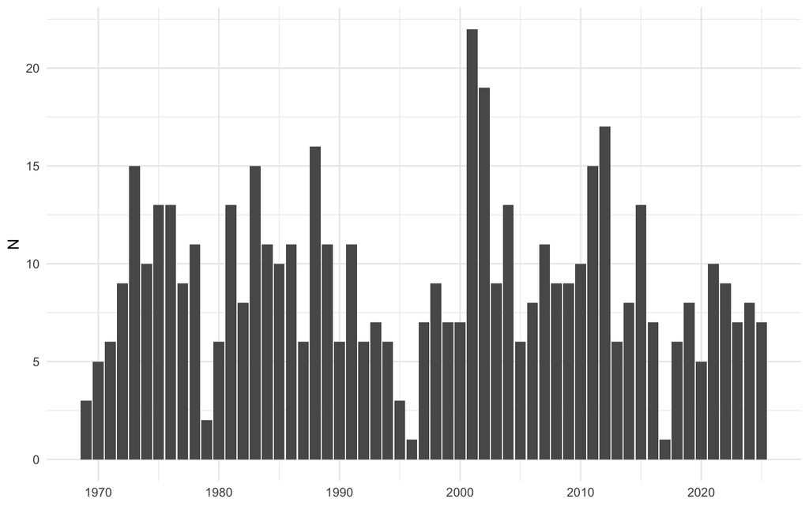

## SCOTUS AdLaw Cases by Process

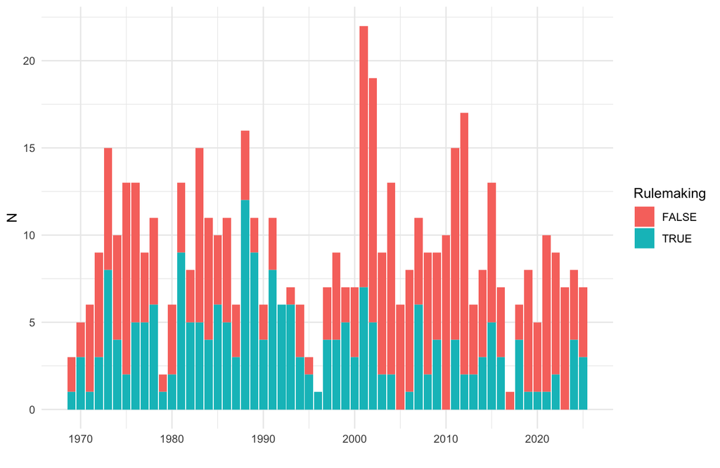

## SCOTUS AdLaw Cases by Agency

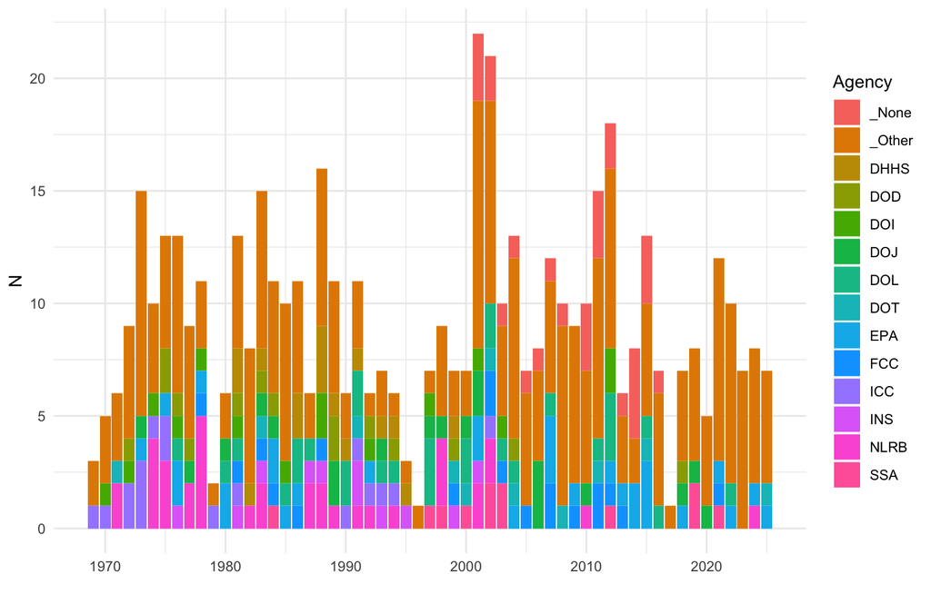

## by Number of Public Comments

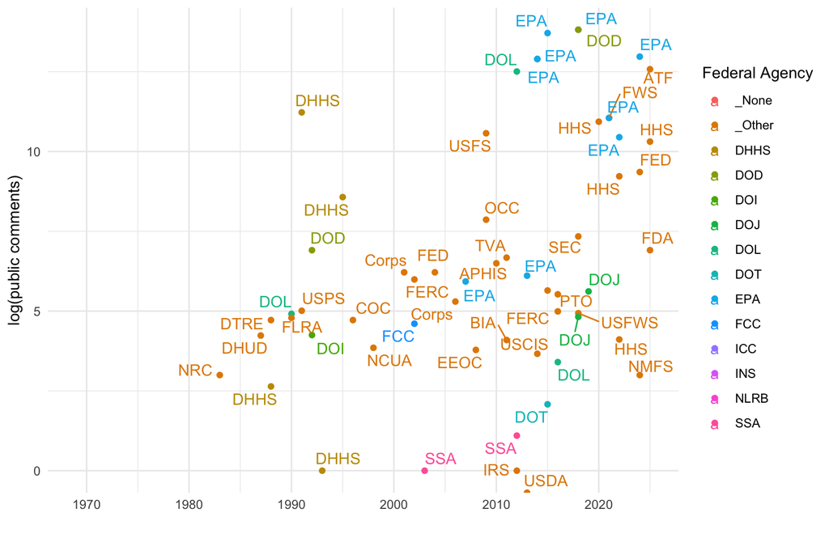

## by Number of Public Comments

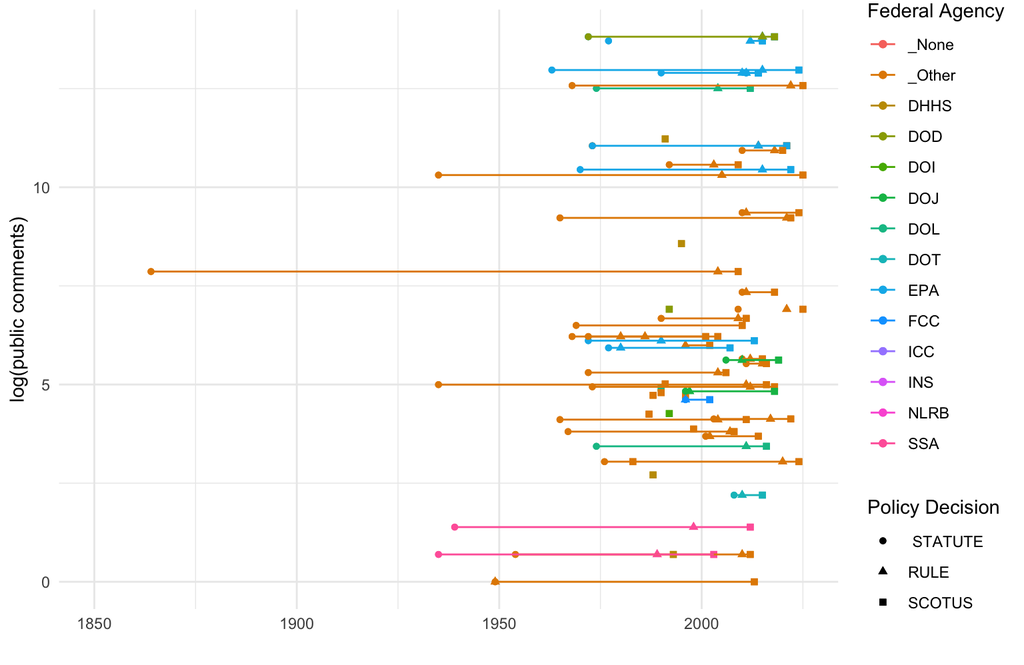

# Preliminary results

### #1. What kinds of policy processes withstand judicial review?

- ❌ - expertise
- ❌ - accountability
- ✅ - participatory/controversial
- ✅ - deregulatory

### #2. Why are policies made through notice and comment more likely to be struck down?

- ❌ - ideological voting
- ❌ - selection from lower courts
- ✅ - controversial/salient (but see #1)

### #3. Was *Chevron/Mead* a regime?

- The jurisprudential regimes debate used 1969-2000 data; I can revisit with 25 years of additional cases

## Log odds of vote for agency

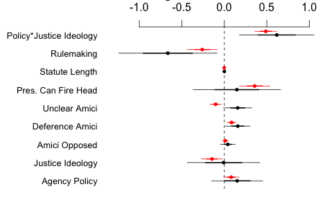

## Log odds of vote for agency

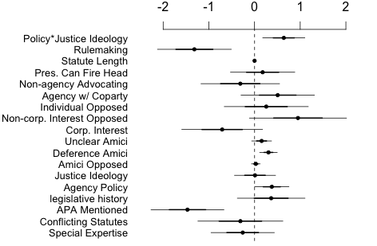